# R For Data Science: Chapter 16 - Dates and times

The notes are taken from [R for Data Science book](https://r4ds.had.co.nz/factors.html).

[Cheatsheet](https://rawgit.com/rstudio/cheatsheets/master/lubridate.pdf)

[JRNold](https://jrnold.github.io/r4ds-exercise-solutions/) [BRShallo](https://brshallo.github.io/r4ds_solutions/16-dates-and-times.html#date-time-components)

## 16.1 Introduction

Dates and times are hard because they have to reconcile two physical phenomena (the rotation of the Earth and its orbit around the sun) with a whole raft of geopolitical phenomena including months, time zones, and DST. This chapter won’t teach you every last detail about dates and times, but it will give you a solid grounding of practical skills that will help you with common data analysis challenges.

### Prerequisites

This chapter will focus on the lubridate package, which makes it easier to work with dates and times in R. lubridate is not part of core tidyverse because you only need it when you’re working with dates/times. We will also need nycflights13 for practice data.

```r
library(tidyverse)

library(lubridate)
library(nycflights13)
```

## 16.2 Creating date/times

Three types:

- a **date** –> shown as `<date>` in tibble
- a **time** –> shown as `<time>` in tibble
- a **date-time** –> shown as `<dttm>` in tibble

For time, use the **hms** package if needed. Going to focus on `date` and `date-time` in this chapter.

To get the current date, use `today()` or `now()`:

```r
today()
```

```
[1] "2020-04-11"
```

```r
now()
```

```
[1] "2020-04-11 13:27:35 CDT"
```

Three ways to create a date/time:

- from string
- from individual time/date component
- from an existing date/time object

### 16.2.1 From strings

```r
ymd("2017-01-31")
```

```
[1] "2017-01-31"
```

```r
mdy("January 31st, 2017")
```

```
[1] "2017-01-31"
```

```r
dmy("31-Jan-2017")
```

```
[1] "2017-01-31"
```

The function also take unquoted numbers. It’s the most concise way:

```r
ymd(20170131)
```

```
[1] "2017-01-31"
```

To create date time, add an underscore and one more of “h”, “m”, and “s” to the name of the parsing function:

```r
ymd_hms("2017-01-31 20:11:59")
```

```
[1] "2017-01-31 20:11:59 UTC"
```

```r
mdy_hm("01/31/2017 08:01")
```

```
[1] "2017-01-31 08:01:00 UTC"
```

We can force a creation of date-time from a date by supplying a timezone:

```r
ymd(20170131, tz="UTC")
```

```
[1] "2017-01-31 UTC"
```

### 16.2.2 From individual components

```r
flights %>%
  select(year, month, day, hour, minute)
```

To create a date/time from this sort of input, use make_date() for dates, or make_datetime() for date-times:

```r
flights %>%
  select(year, month, day, hour, minute) %>%
  mutate(departure = make_datetime(year,month,day,hour,minute))
```

| year | month | day | hour | minute | departure |
| --- | --- | --- | --- | --- | --- |
| 2013 | 1 | 1 | 5 | 15 | 2013-01-01 05:15:00 |
| 2013 | 1 | 1 | 5 | 29 | 2013-01-01 05:29:00 |
| 2013 | 1 | 1 | 5 | 40 | 2013-01-01 05:40:00 |
| 2013 | 1 | 1 | 5 | 45 | 2013-01-01 05:45:00 |
| 2013 | 1 | 1 | 6 | 0 | 2013-01-01 06:00:00 |
| 2013 | 1 | 1 | 5 | 58 | 2013-01-01 05:58:00 |
| 2013 | 1 | 1 | 6 | 0 | 2013-01-01 06:00:00 |
| 2013 | 1 | 1 | 6 | 0 | 2013-01-01 06:00:00 |
| 2013 | 1 | 1 | 6 | 0 | 2013-01-01 06:00:00 |
| 2013 | 1 | 1 | 6 | 0 | 2013-01-01 06:00:00 |

[output cut: 990 more lines]

Let’s do the same thing for the four time columns in `flights`.

```r
make_datetime_100 <- function(year, month, day, time) {
  make_datetime(year, month, day, time %/% 100, time %% 100)
}

flights_dt <- flights %>%
  filter(!is.na(dep_time), !is.na(arr_time)) %>%
  mutate(
    dep_time = make_datetime_100(year, month, day, dep_time),
    arr_time = make_datetime_100(year, month, day, arr_time),
    sched_dep_time = make_datetime_100(year, month, day, sched_dep_time),
    sched_arr_time = make_datetime_100(year, month, day, sched_arr_time)
  ) %>%
  select(origin, dest, ends_with("delay"), ends_with("time"))

flights_dt
```

| origin | dest | dep_delay | arr_delay | dep_time | sched_dep_time | arr_time | sched_arr_time | air_time |
| --- | --- | --- | --- | --- | --- | --- | --- | --- |
| EWR | IAH | 2 | 11 | 2013-01-01 05:17:00 | 2013-01-01 05:15:00 | 2013-01-01 08:30:00 | 2013-01-01 08:19:00 | 227 |
| LGA | IAH | 4 | 20 | 2013-01-01 05:33:00 | 2013-01-01 05:29:00 | 2013-01-01 08:50:00 | 2013-01-01 08:30:00 | 227 |
| JFK | MIA | 2 | 33 | 2013-01-01 05:42:00 | 2013-01-01 05:40:00 | 2013-01-01 09:23:00 | 2013-01-01 08:50:00 | 160 |
| JFK | BQN | -1 | -18 | 2013-01-01 05:44:00 | 2013-01-01 05:45:00 | 2013-01-01 10:04:00 | 2013-01-01 10:22:00 | 183 |
| LGA | ATL | -6 | -25 | 2013-01-01 05:54:00 | 2013-01-01 06:00:00 | 2013-01-01 08:12:00 | 2013-01-01 08:37:00 | 116 |
| EWR | ORD | -4 | 12 | 2013-01-01 05:54:00 | 2013-01-01 05:58:00 | 2013-01-01 07:40:00 | 2013-01-01 07:28:00 | 150 |
| EWR | FLL | -5 | 19 | 2013-01-01 05:55:00 | 2013-01-01 06:00:00 | 2013-01-01 09:13:00 | 2013-01-01 08:54:00 | 158 |
| LGA | IAD | -3 | -14 | 2013-01-01 05:57:00 | 2013-01-01 06:00:00 | 2013-01-01 07:09:00 | 2013-01-01 07:23:00 | 53 |
| JFK | MCO | -3 | -8 | 2013-01-01 05:57:00 | 2013-01-01 06:00:00 | 2013-01-01 08:38:00 | 2013-01-01 08:46:00 | 140 |
| LGA | ORD | -2 | 8 | 2013-01-01 05:58:00 | 2013-01-01 06:00:00 | 2013-01-01 07:53:00 | 2013-01-01 07:45:00 | 138 |

[output cut: 990 more lines]

With this data, I can visualise the distribution of departure times across the year:

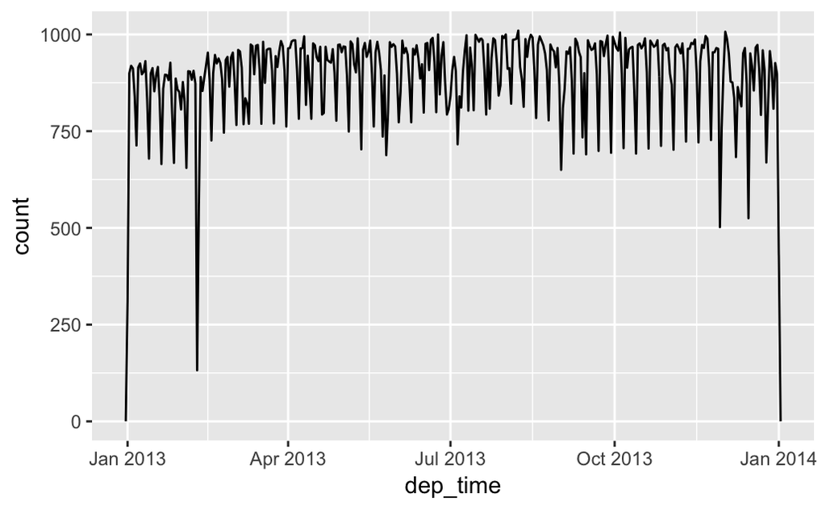

```r
flights_dt %>%
  ggplot(aes(dep_time)) +
  geom_freqpoly(binwidth = 86400) # 86400 seconds = 1 day
```

Or within a single day:

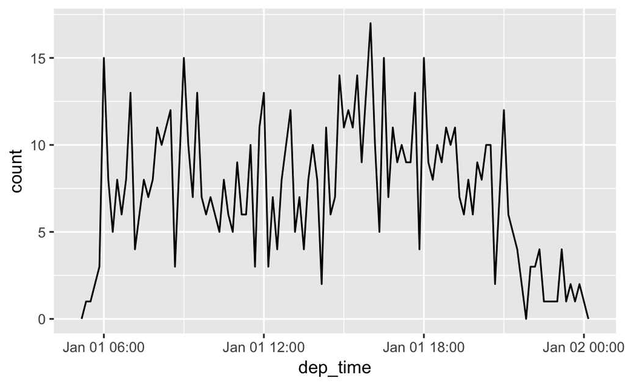

```r
flights_dt %>%
  filter(dep_time < ymd(20130102)) %>%
  ggplot(aes(dep_time)) +
  geom_freqpoly(binwidth = 600) # 600 s = 10 minutes
```

```r
flights_dt %>%
  ggplot(aes(dep_time)) +
  filter(dep_time < ymd(20130203)) %>%
  geom_freqpoly(binwidth = 600) # 600 s = 10 minutes
```

```
Error in filter(dep_time < ymd(20130203)) : object 'dep_time' not found
```

```r
ymd_hms('2012-06-01     12:23')
```

```
[1] "2020-12-06 01:12:23 UTC"
```

Note that when you use date-times in a numeric context (like in a histogram), 1 means 1 second, so a binwidth of 86400 means one day. For dates, 1 means 1 day.

### 16.2.3 From Other Types

You may want to switch between a date-time and a date. That’s the job of as_datetime() and as_date():

```r
as_datetime(today())
```

```
[1] "2020-04-11 UTC"
```

```r
as_date(now())
```

```
[1] "2020-04-11"
```

Sometimes you’ll get date/times as numeric offsets from the “Unix Epoch”, 1970-01-01. If the offset is in seconds, use as_datetime(); if it’s in days, use as_date().

```r
# 10 hours after 3600 seconds:
as_datetime(60*60*10)
```

```
[1] "1970-01-01 10:00:00 UTC"
```

```r
# 365 days * 10 add two for the two leap years in between
as_date(365*10+2)
```

```
[1] "1980-01-01"
```

### 16.2.4 Exercises

#### 1. What happens if you parse a string that contains invalid dates?

```r
ymd(c("2010-10-10", "bananas"))
```

```
 1 failed to parse.
```

```
[1] "2010-10-10" NA
```

#### 2. What does the tzone argument to today() do? Why is it important?

```r
# OlsonNames()
today(tzone="Asia/Ulaanbaatar")
```

```
[1] "2020-04-12"
```

```r
now(tzone="Asia/Ulaanbaatar")
```

```
[1] "2020-04-12 04:39:51 +08"
```

It changes the time zone into various places in the world.

#### 3. Use the appropriate lubridate function to parse each of the following dates:

```r
d1 <- "January 1, 2010"
mdy(d1)
d2 <- "2015-Mar-07"
ymd(d2)
d3 <- "06-Jun-2017"
dmy(d3)
d4 <- c("August 19 (2015)", "July 1 (2015)")
mdy(d4)
d5 <- "12/30/14" # Dec 30, 2014
mdy(d5)
```

## 16.3 Date-time Components

What can we do with date-time components? Focus on the **accessor function** –> getting and setting individual components.

### 16.3.1 Getting components

Getting components such as: `year()`, `month()`, `mday()` (day of the month), `yday()` (day of the year), `wday()` (day of the week), `hour()`, `minute()`, and `second()`.

```r
datetime1 <- ymd_hms("2016-07-08 12:34:56")
year(datetime1)
```

```
[1] 2016
```

```r
month(datetime1)
```

```
[1] 7
```

```r
mday(datetime1)
```

```
[1] 8
```

```r
yday(datetime1)
```

```
[1] 190
```

```r
wday(datetime1)
```

```
[1] 6
```

For `month()` and `wday()`, you can set `label=TRUE` to return the abbreviated name of the month or day of the week. Set `abbr=FALSE` to return the full name.

```r
month(datetime1,label=TRUE)
```

```
[1] Jul
12 Levels: Jan < Feb < Mar < Apr < May < Jun < Jul < Aug < ... < Dec
```

```r
wday(datetime1,label=TRUE,abbr=FALSE)
```

```
[1] Friday
7 Levels: Sunday < Monday < Tuesday < Wednesday < ... < Saturday
```

We can use wday() to see that more flights depart during the week than on the weekend:

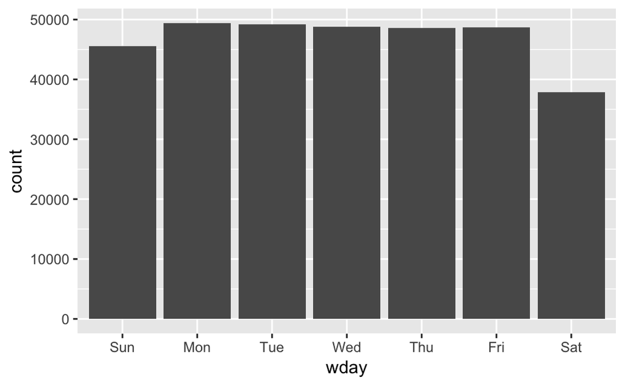

```r
flights_dt %>%
  mutate(wday = wday(dep_time, label = TRUE)) %>%
  ggplot(aes(x = wday)) +
    geom_bar()
```

Pattern if we look at the average departure delay by minute within the hour. It looks like flight leaving in minute 20-30 and 50-60 have much lower delays than the rest of the hour.

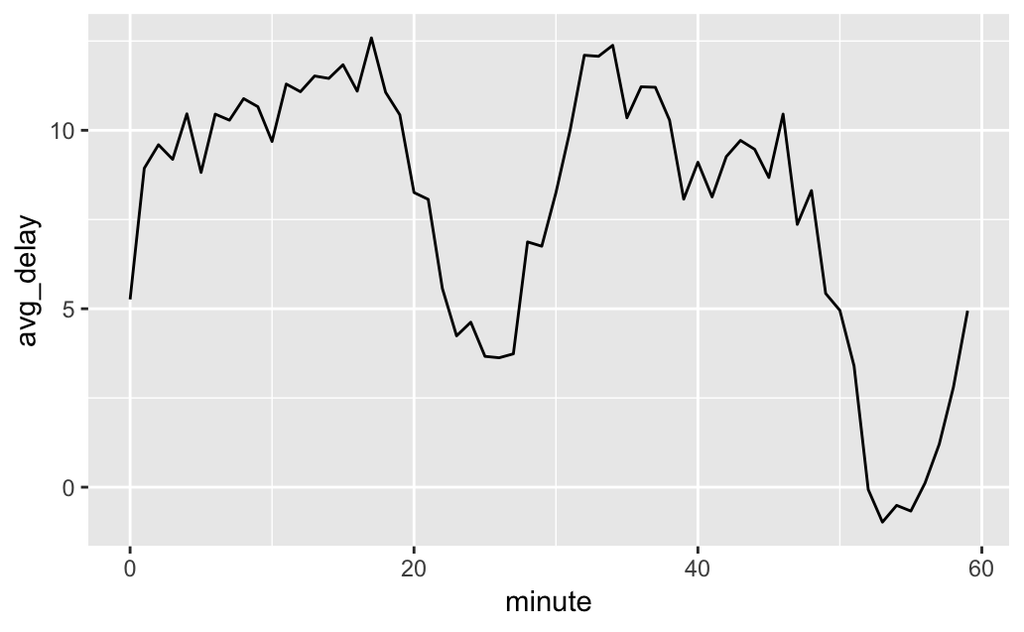

```r
flights_dt %>%
  mutate(minute = minute(dep_time)) %>%
  group_by(minute) %>%
  summarise(
    avg_delay = mean(arr_delay, na.rm = TRUE),
    n = n()) %>%
  ggplot(aes(minute, avg_delay)) +
    geom_line()
```

There is no pattern for *scheduled* departure time:

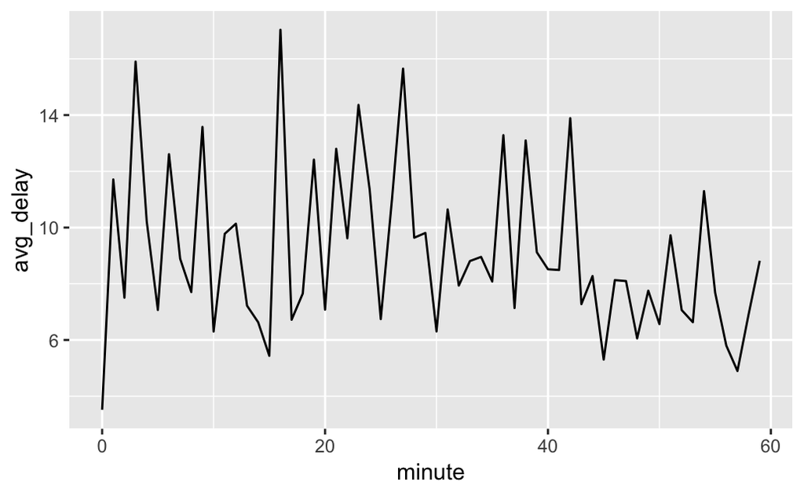

```r
sched_dep <- flights_dt %>%
  mutate(minute = minute(sched_dep_time)) %>%
  group_by(minute) %>%
  summarise(
    avg_delay = mean(arr_delay, na.rm = TRUE),
    n = n())

ggplot(sched_dep, aes(minute, avg_delay)) +
  geom_line()
```

Why do we see pattern with actual departure time? There is bias for leaving at “nice” times!

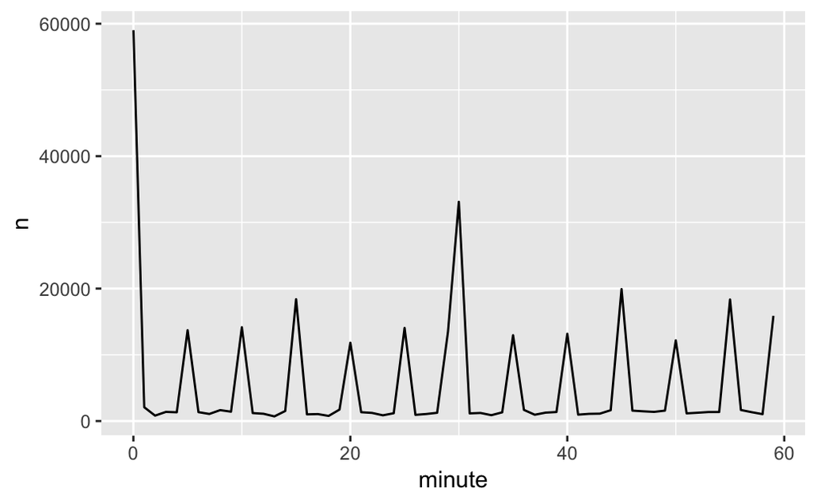

```r
ggplot(sched_dep, aes(minute, n)) +
  geom_line()
```

### 16.3.2 Rounding

There is a way is to round the date to a nearby unit of time, with `floor_date()`, `round_date()`, and `ceiling_date()`. Here is an example:

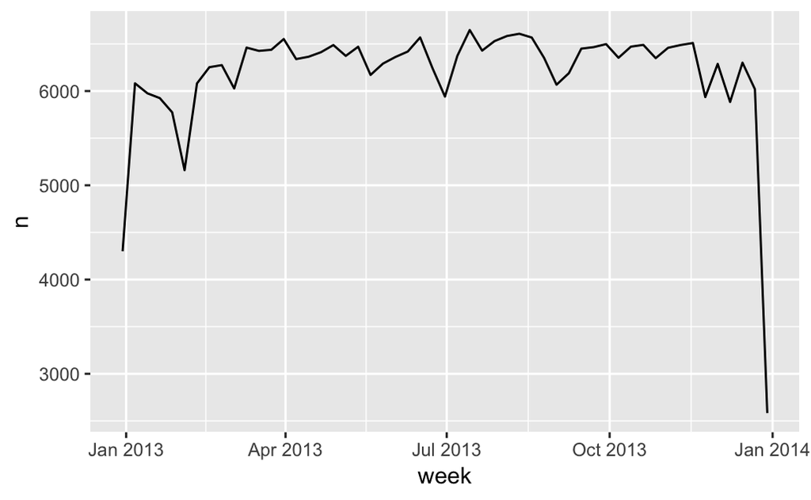

```r
flights_dt %>%
  count(week=floor_date(dep_time,"week")) %>%
  ggplot(aes(week,n)) +
  geom_line()
```

Computing the difference between a rounded and unrounded date can be particularly useful.

### 16.3.3 Setting Components

To set the components of a date/time:

```r
(datetime1 <- ymd_hms("2016-07-08 12:34:56"))
```

```
[1] "2016-07-08 12:34:56 UTC"
```

```r
year(datetime1) <- 2020
month(datetime1) <- 01
datetime1
```

```
[1] "2020-01-08 12:34:56 UTC"
```

```r
hour(datetime1) <- hour(datetime1) + 1
datetime1
```

```
[1] "2020-01-08 13:34:56 UTC"
```

Create a new date-time with `update()`. We can set multiple values at one:

```r
update(datetime1, year = 2020, month = 2, mday = 2, hour = 2)
```

```
[1] "2020-02-02 02:34:56 UTC"
```

If values are too big, they will roll-over:

```r
ymd("2015-02-01") %>%
  update(mday = 30)
```

```
[1] "2015-03-02"
```

```r
ymd("2015-02-01") %>%
  update(hour = 400)
```

```
[1] "2015-02-17 16:00:00 UTC"
```

Use `update()` to show the distribution of the flights across the course of the day for every day of the year:

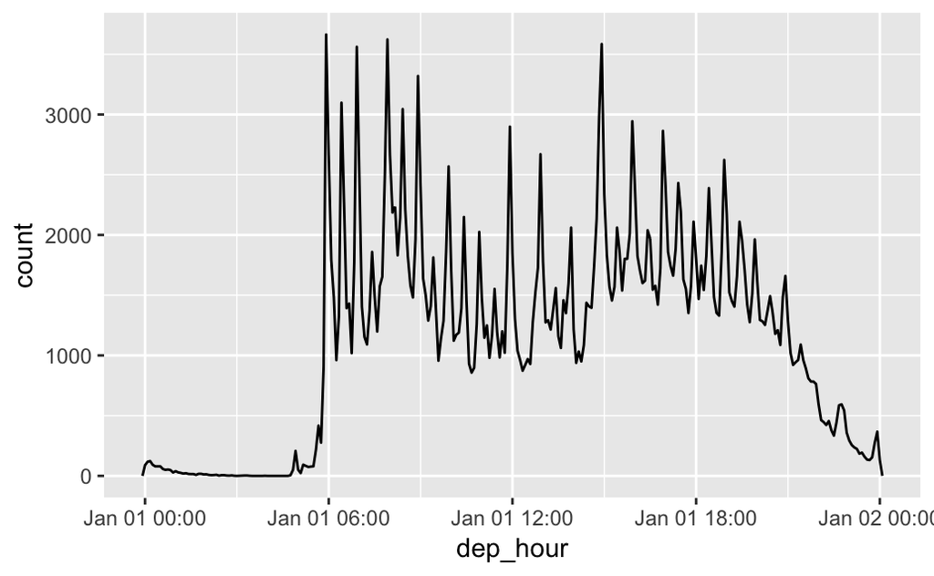

```r
flights_dt %>%
  mutate(dep_hour = update(dep_time, yday = 1)) %>%
  ggplot(aes(dep_hour)) +
    geom_freqpoly(binwidth = 300)
```

Setting larger components of a date to a constant is a powerful technique that allows you to explore patterns in the smaller components.

### 16.3.4 Exercises

#### 1. How does the distribution of flight times within a day change over the course of the year?

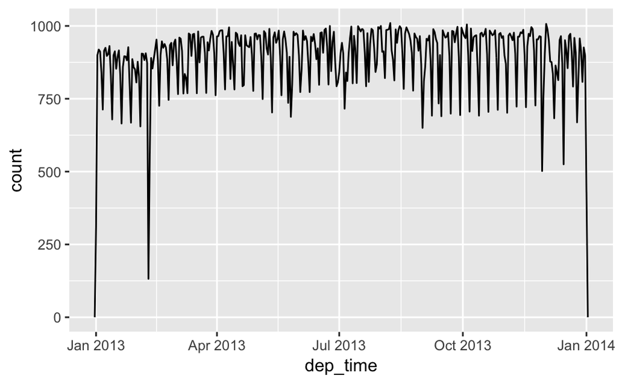

```r
flights_dt %>%
  ggplot(aes(dep_time))+
  geom_freqpoly(binwidth=86400)
```

```r
flights_dt %>%
  transmute(quarter_dep = quarter(dep_time)%>% factor(),
            day_dep = as_date(dep_time),
            dep_time = as.hms(dep_time)) %>%
  group_by(quarter_dep,day_dep) %>%
  summarise(day_median =  median(day_dep))
```

#### 2. Compare dep_time, sched_dep_time and dep_delay. Are they consistent? Explain your findings.

```r
flights_dt %>%
  mutate(comp_dep_delay = dep_time-sched_dep_time,
         dep_delay = seconds(comp_dep_delay),
         comp_dep_delay = seconds(comp_dep_delay),
         diff = dep_delay-comp_dep_delay) %>%
  select(dep_delay,comp_dep_delay,diff)
```

| dep_delay | comp_dep_delay | diff |
| --- | --- | --- |
| 120S | 120S | 0S |
| 240S | 240S | 0S |
| 120S | 120S | 0S |
| -60S | -60S | 0S |
| -360S | -360S | 0S |
| -240S | -240S | 0S |
| -300S | -300S | 0S |
| -180S | -180S | 0S |
| -180S | -180S | 0S |
| -120S | -120S | 0S |

[output cut: 990 more lines]

#### 4. How does the average delay time change over the course of a day? Should you use dep_time or sched_dep_time? Why?

```r
library(hms)
```

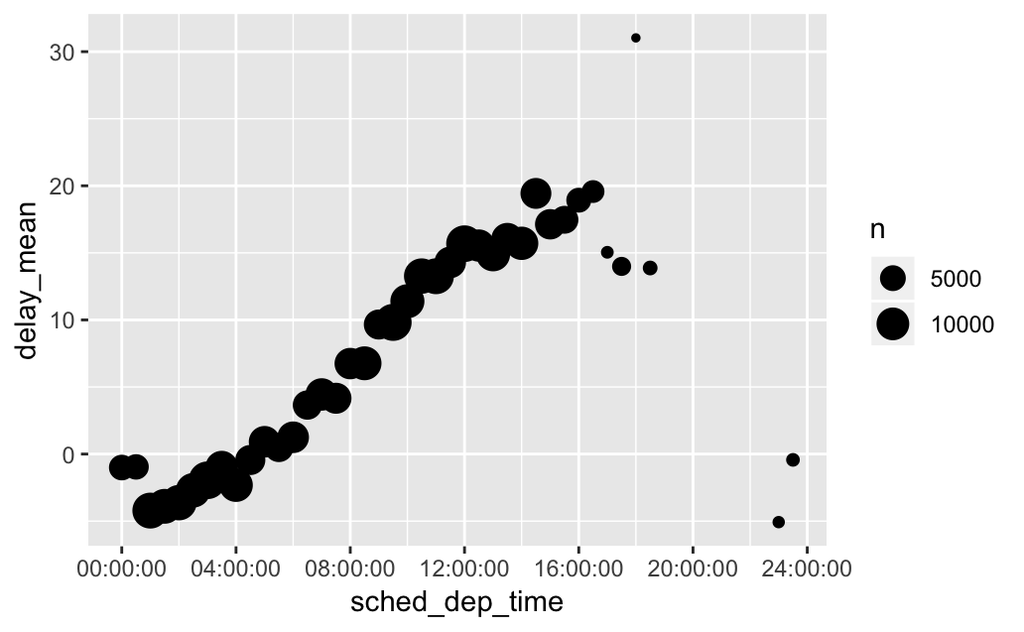

```r
flights_dt %>%
  mutate(sched_dep_time = as.hms(floor_date(sched_dep_time, "30 mins"))) %>%
  group_by(sched_dep_time) %>%
  summarise(delay_mean = mean(arr_delay, na.rm = TRUE),
            n = n(),
            n_na = sum(is.na(arr_delay)) / n,
            delay_median = median(arr_delay, na.rm = TRUE)) %>%
  ggplot(aes(x = sched_dep_time, y = delay_mean, size = n)) +
  geom_point()
```